# 红葡萄酒数据分析

# 多变量分析

### 谈谈你在这部分对各变量关系的发现。各个变量互相作用下对你感兴趣的变量是否产生影响？

酒精含量、醋酸含量、硫酸钾、柠檬酸均会影响质量分数，但由于醋酸和柠檬酸负相关（相关系数-0.55），在建立数学模型时，我舍去柠檬酸这一参数。

### 有没有令你感兴趣或者吃惊的发现？

我发现随着随着柠檬酸的提高，醋酸的含量会降低。我分析，柠檬酸具有抗氧化的作用，而醋酸是由乙醇氧化而生成的；所以柠檬酸抑制了醋酸的生成。

### 可选，你是否针对你的数据集创建了数学模型？谈谈你的数学模型的能力和局限性。

我对数学模型为:  
quality = 2.611 + 0.309 ×alcohol - 1.221 × volatile.acidity + 0.679 × sulphates  
这个模型考虑了酒精含量、醋酸和硫酸钾对质量分数的影响。这个线性模型相比人打分要客观，人打分本身就有主观因素，而且打分时取整数也会造成误差。  
这个数学模型中的参数对质量分数贡献了33.6%，显然这个模型的精度比较低。

# 最后的图和总结

### 图1

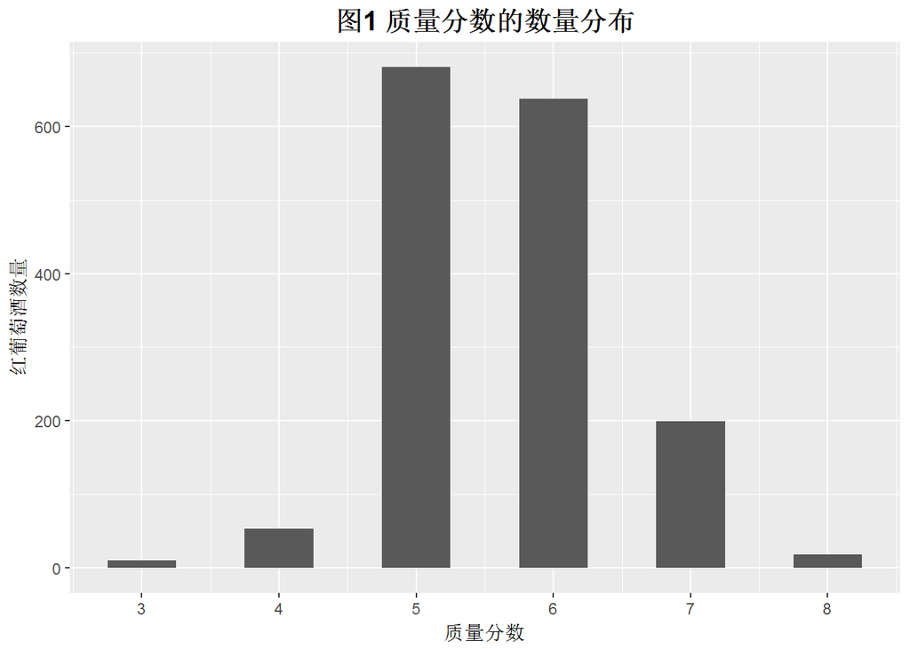

### 图1的描述

通过图1可知，红葡萄酒质量分数大部分都在5分或者6分，5分和6分的个数都超过600个，7分接近200个，3分、4分、8分的数量很少。说明得3分、4分的概率很低，但是想要达到8分或8分以上的高分也是非常困难的。

### 图2

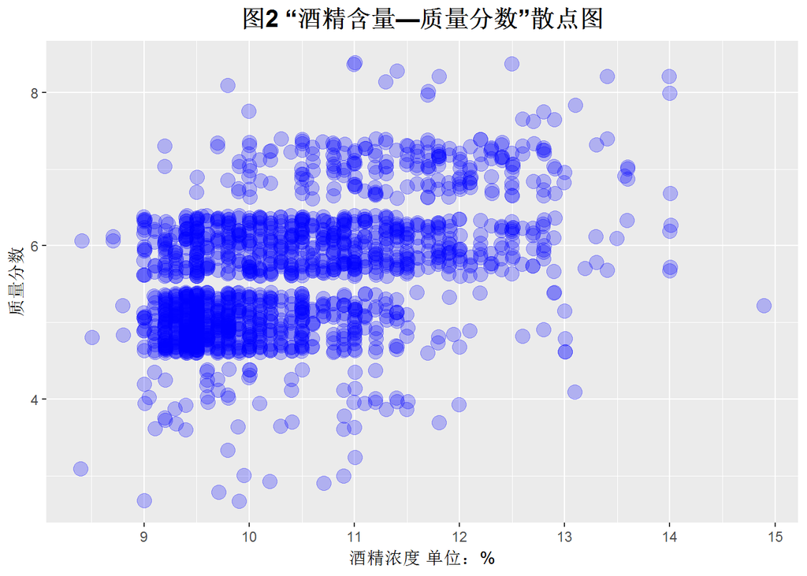

### 图2的描述

从图2中可以看出，大部分的红酒的酒精浓度为9%到11%之间，分数集中在5分和6分；随着酒精浓度上升，质量分数也响应提高。得8分的红酒的酒精浓度大多在11%以上。得3分红酒的酒精浓度都小于等于11%。说明品酒师对酒精浓度还是非常敏感的，红酒的度数直接影响最后的得分。

### 图3

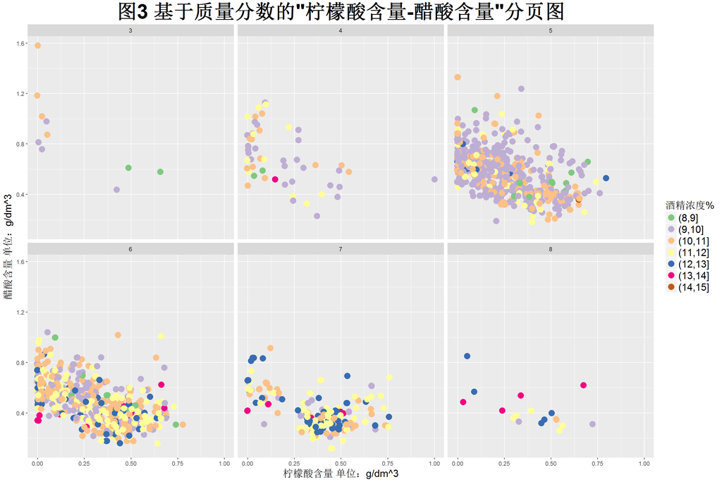

### 图3描述

6张图代表6种不同的质量分数；横坐标是柠檬酸，纵坐标是醋酸；每张图都表现了随着柠檬酸含量的提高，醋酸的含量就会降低的趋势，我认为，柠檬酸具有抗氧化的作用，而醋酸是由乙醇氧化而生成的；所以柠檬酸抑制了醋酸的生成。圆点大多集中在5分和6分这两幅图中。代表酒精浓度高的点（红色、蓝色、黄色）大多集中在6分、7分、8分这3张图上；相反，3分和4分图上的点多为紫色、橙色、绿色，即酒精浓度低。

# 总结和反思